# Initial Project Notes

Scraping a Page

# First Draft

- I selected IG I<sup>2</sup> 1086 as the first inscription to be scraped
- It was very successful!

```r
source("ScrapingPackhum/IG I2 1086.r")
```

```
[1] "IG I²"
[1] "1086"
[1] "PH1825"
[1] "Ἐλεφαντίδος εἰμὶ hιερός."
```

- Outputs are:
  - the book
  - the inscription number
  - the Packard Humanities internal reference number
  - the text

## Breakdown

- The script performs five distinct functions
  - Scraping the target website
  - Finding the book identifiers
  - Finding the PackHum identifier
  - Finding the text
  - Printing the output

## 0) Setup

The script as is calls two packages: `dplyr` and `rvest`. `dplyr` is used for data manipulation and `rvest` for web scraping.

## 1) Target Website

The script begins by turning the target website into the variable `link`. This is then passed through `read_html()`, which scrapes the target webpage. The output is stored as the variable (web)`page`.

```r
### GRAB PAGE ------------------------------------------------------------------
link <- 'https://inscriptions.packhum.org/text/1825?&bookid=3&location=1701'
page <- read_html(link)
```

## 2) Book Identifiers

The script then needs to store which inscription it is scraping. This info has two components: the volume of the Inscriptiones Graecae, and the inscription number.

First, the volume. The command `html_nodes()` searches the `page` for the volume using its selector path. This is copied from the website using Safari’s developer panel. The minimal selector path for this volume is `"span.fullref > a"`. This data is then cleaned of any html tags using `html_text()`. Escape characters, specifically the newline character `\n`, are removed using Regular Expression and the command `gsub()`. The clean text which results is stored as the variable `IGbook`.

The inscription number is selected by the same method, using the selector path `"span.fullref > span"`. The data is stored as the variable `IGno`.

```r
### GRAB TEXT REF --------------------------------------------------------------
#textpage > div.hdr2 > span.fullref > a
IGbook <- page %>% html_nodes("span.fullref > a") %>% html_text()
  IGbook <- gsub("\\n", "", IGbook)

#textpage > div.hdr2 > span.fullref > span
IGno <- page %>% html_nodes("span.fullref > span") %>% html_text()
  IGno <- gsub("\\n", "", IGno)
```

## 3) Packard Humanities Identifier

Every inscription in the Packard Humanities Institute library includes a unique reference number. For the purposes of the study, this number fills two roles. First, since each number is unique, it may be used as a global identifier in contrast to the local identifiers found in §2. Every volume of the Inscriptiones Graecae will contain an inscription called 1, and 2, etc. These may be distinguished using the volume number, or by using the PHI inscription number. For example, the inscription IG I<sup>2</sup> 1086 is the only one with the PHI inscription number PH1825.

Second, this reference number is included in the web address. See the link:

```r
link <- 'https://inscriptions.packhum.org/text/1825?&bookid=3&location=1701'
```

The number `1825` is indeed the PHI inscription number, with the prefix “PH” removed. The result is that this number may be used to systematically scrape every inscription from the PHI website. This idea is to be tested next.

The PHI inscription number is grabbed in the same manner as `IGbook` and `IGno`, with the cleaned data stored as the variable `PHIno`.

```r
### GRAB PACKHUM REF -----------------------------------------------------------
#textpage > div.docref
PHIno <- page %>% html_nodes('div.docref') %>% html_text()
  PHIno <- gsub("\\n", "", PHIno)
```

## 4) The Inscription

The inscription is scraped in the same manner as the past three variables. The major difference is in the cleaning step: the inscriptions often contain editorial marks which must be removed before any analysis.

The list of marks to be removed will be updated as more arise.

```r
### GRAB TEXT ------------------------------------------------------------------
#textpage > div.text > div.greek.text-nowrap.dblclk > table
text <- page %>% html_nodes('div.greek.text-nowrap.dblclk') %>% html_text()
  text <- gsub("\\n", "", text)
  text <- gsub("\\d", "", text)
  text <- gsub("-", "", text)
  #ℎ PLANCK CONSTANT Unicode: U+210E, UTF-8: E2 84 8E
  text <- gsub("ℎ", "h", text)
```

# Second Draft

The script currently prints the scraped data onto the console. This is fine when working with a single inscription, but will quickly become unusable when scraping more pages. The variables `IGbook`, `IGno`, `PHIno`, and `text` should be redefined as lists.

Since I’m planning ahead, I suppose I should wrap the scraping into functions.

## Designing the Loop

The Packard Humanities Reference Number is *also the identifying portion of the web address!* Everything after the ampsersand in the above address, `https://inscriptions.packhum.org/text/1825?&bookid=3&location=1701`, is added while navigating through the website’s tree of variables (volume, region, etc.). The script can therefore be built around a `for()` loop which α) builds a new variable for each loop and β) checks to ensure the resulting web address corresponds to a valid PHI Reference Number.

## The Function

The loop is built around a function, currently called `TEST()`, which captures and organizes the data for us.

```r
TEST <- function(PHIno = 20) {
  link <- paste('https://inscriptions.packhum.org/text/', PHIno, sep="")
  page <- read_html(link)

  ### Text
  #textpage > div.text > div.greek.text-nowrap.dblclk > table
  text <- page %>% html_nodes('div.greek.text-nowrap.dblclk') %>% html_text()
  text <- gsub("[\\d\\[\\]]", "", text, perl=T)
  text <- gsub("(\\-\\n{1,})", "", text, perl=T)
  text <- gsub("\\n{1,}", "", text, perl=T)
  text <- gsub("\\s{1,}", " ", text, perl=T)
  # ̣COMBINING DOT BELOW Unicode: U+0323, UTF-8: CC A3
  text <- gsub("̣", "", text, perl=T)
  text <- gsub("#", "", text, perl=T)
  # ℎ PLANCK CONSTANT Unicode: U+210E, UTF-8: E2 84 8E
  text <- gsub("ℎ", "h", text, perl=T)

  ### IGBook
  #textpage > div.hdr2 > span.fullref > a
  IGbook <- page %>% html_nodes("span.fullref > a") %>% html_text()
  IGbook <- gsub("\\n", "", IGbook)

  ### IGNo
  IGno <- page %>% html_nodes("span.fullref > span") %>% html_text()
  IGno <- gsub("\\n", "", IGno)

  # Atm keeping for debugging
  # print(link)
  # print(text)
  # print(IGbook)
  # print(IGno)
  # print(PHIno)

  # Make entry to be returned
  entry <- c(IGbook, IGno, PHIno, text, link)
  return(as.list(entry))

  # Atm keeping for debugging
  # rm(link)
  # rm(text)
  # rm(IGbook)
  # rm(IGno)
  # rm(PHIno)
}
```

This essentially encapsulates the contents of the first draft. The main differences are in the formatting changes (more notational marks to be removed) and how it handles the output. Rather than printing off variables to the terminal, the function creates a vector called `entry`, which it returns as a list for later processing. The target `PHIno` is now also identified as an argument of the function. The default `PHIno` is 20 (IG I^3 20), because it’s an eyesore and I’m a masochist. Or because I slammed it in at random. WHo’s to say.

There are also a few test lines at the bottom that use the `TEST()` function in a `for()` loop to gather the first 100 inscriptions (by `PHIno`) from the PackHum website.

```r
# df[row, column]
test_df <- tibble(Book = NA, No = NA, Ref = NA, Text = NA, Link = NA)
test_df[1,] <- TEST(1)
test_df[2,] <- TEST(2)
test_df[3,] <- TEST(3)

for (i in c(1:100)) {
  test_df[i,] <- TEST(i)
}
```

|  | Book | No | Ref | Text | Link |
| --- | --- | --- | --- | --- | --- |
| 1 | IG I³ | 1 | 1 | ἔδοχσεν το͂ι δέμοι· τὸς ἐ Σαλαμῖνι κλερόχοςοἰκε͂ν ἐᾶ Σαλαμῖνι ․․․․λεν ․․․․․․ Ἀθένεσι τελε͂ν καὶ στρατεύεσθαι ⋮ τὰ δ’ ἐ Σαλαμῖνι μὲ μισθο͂ν, ἐὰ μὲ οἰκ․․․․․․ο․ μισθόμενο․ ⋮ ἐὰν δὲ μισθο͂ι, ἀποτίνεν τὸ μ… | https://inscriptions.packhum.org/text/1 |
| 2 | IG I³ | 2 | 2 | ․․-․․․ν βολ — — — — — — — — — —․-․․⁷α ⋮ hεκον — — — — — — —․σιον, γνοσθε͂ι δὲ — — — — — — — —․ν ἀτεχνος ⋮ μὲ π— — — — — ἄλλοθι δὲ μεδὲ hαμο͂ — — — — — — — — — —κελεύοσι ⋮ χινχάνεν — — — — — — —ἐπιδικά… | https://inscriptions.packhum.org/text/2 |
| 3 | IG I³ | 3 | 3 | ․αρ․․․․ι hερακλειο․․․․․αρο⁷․ τιθέναι τὸς ἀθλοθέτας· τριάκοντα ἄνδρας δὲτὸν ἀγο͂να ἐπιόφσασθαι ἐκτο͂ν ἐπιδέμομ, τρε͂ς ἐκ φυλε͂ς hεκάστες, hυποσχομένος ἐν το͂ι hιερο͂ι ὁς ἂν οἷόν τ’ ἐ͂ι χσυνδιαθέσεν τὸ… | https://inscriptions.packhum.org/text/3 |
| 4 | IG I³ | 4 | 4 | face A.․․․․․․․․․․․․․․․․․․․․․․․․․․․․․․․․․․․․․․․․․․․․․․․․․․․․․․․․․․․․․․․․․․․․․․․․․․․․․․․․․․․․․․․․․․․․․․․․․ ἐὰν δέ τις ․․․․․․․․․․․․․․․․․․․․․․․․․․αν ⋮ ἒ φρορὰν ⋮ μὲ ․․․․․․․․․․․․․․․․․․ πεντέκοντα ⋮ δραχμὰς… | https://inscriptions.packhum.org/text/4 |
| 5 | IG I³ | 5 | 5 | ἔδοχσεν ⋮ τε͂ι βολε͂ι ⋮ καὶ το͂ι δέμοι ⋮ hότε Παραιβάτες ⋮ ἐγραμμάτευε vac.προτέλεια ⋮ θύεν ⋮ τὸς hιεροποιὸς ⋮ Ἐλευσινίον ⋮ καὶ τἄλλα ⋮ ἐς τὲν ἑορτὲντὲν Ἐλευσῖνι ⋮ Γε͂ι ⋮ hερμε͂ι Ἐναγονίοι ⋮ Χάρισιν ⋮… | https://inscriptions.packhum.org/text/5 |
| 6 | IG I³ | 6 | 6 | face A.BM .— — — — — — — — — — — — —․․․․․․․․․․․․․ δραχμε͂ισι ․․․․․․․․․․․․τες τὸς ιο․․․․․․․․․․․․μενος δεμο․․․․․․․․․․․․ το͂ν πόλεον․․․․․․․․․․ δοκε͂ι ⋮ ἀνατιθ․․․․․․․․․․․α ⋮ ἐάν τις το͂ν․․․․․․․․․․․․․ον ἒ … | https://inscriptions.packhum.org/text/6 |

## Bad Links

Now, trying to scan a non-existent page will obviously break things. An example from the draft:

```r
# testing bad selector paths ---------------------------------------------------
test_prime <- tibble(Book = NA, No = NA, Ref = NA, Text = NA, Link = NA)
test_prime[1,] <- TEST(0)
```

```
Error: Can't recycle input of size 2 to size 5.
Run `rlang::last_error()` to see where the error occurred.
```

```r
TEST(0)
```

```
[[1]]
[1] "0"

[[2]]
[1] "https://inscriptions.packhum.org/text/0"
```

There is also the option where I manually define the ranges which I intend to gather. This would avoid *scanning the Inscriptiones Graecae in its entirety*, but would raise the chances of missing potential data.

After some thought, I’m of the opinion that I should use a function for link validation. Assuming the code works, a programmatic approach should outperform a manual search by every metric. This makes sense! It’s a repetitive task that would normally take many long hours to complete. It’s everything a computer excels at!

What’s more, the output of the loop could be used as the limiter for any `for()` loops, improving the function’s control and reproducibility.

|  | Automated | Manual | Assuming the code works … |
| --- | --- | --- | --- |
| Time (Coding) | - | + | Manual isn’t coded |
| Time (Search) | + | - | Automated does it for you |
| Output as Obj. | + | - | Output can be used as `i` |
| Thematic | + | - | Paper is about programming |
| Missed Links | + | - | Code will try every possible option |
| Volume per TIme | + | - | Code will scan more in same time |
| False pos/neg | + | - | Code won’t mistake a 0 for other `n` |

The matter of time brings up another point. Currently, I have no estimate for how long anything will take to run. While this isn’t a problem for smaller code chunks, it may become a major factor in the full-scale scraper/miner. My laptop isn’t built to handle that kind of network or memory load, and I can’t use the GAI servers without my Dell, so this *needs to work* when I scale up. I literally cannot run this repeatedly, I just do not have that kind of time on my hands.

Time benchmarking is a faster fix, so that’ll come first.

## Time Benchmarks

There are two options for measuring time elapsed during execution.

```
1       Sys.time()
2       system.time(FUNC())
```

`Sys.time()` returns the current time.

```r
Sys.time()
```

```
[1] "2022-06-10 15:03:47 EDT"
```

`system.time(FUNC())` returns the execution time of some arbitrary function FUNC(). It looses the output of the argument.

```r
system.time(TEST(200))
```

```
   user  system elapsed
  0.042   0.010   1.269
```

Current plan. Capture a timestamp at the beginning of execution. Capture another at the end. Find the difference!

```r
# Capture first time stamp
test_time_a <- Sys.time()

# Wait for 20 seconds
Sys.sleep(5)

# Capture last time stamp
test_time_b <- Sys.time()

# Find difference
test_time_b - test_time_a
```

```
Time difference of 5.010035 secs
```

Now, adding `Sys.time()` directly to the function seems unnecessary. I don’t want to complicate things by adding more outputs to a function, plus I don’t really care how long it takes to capture the individual page. I’m more interested in how long it takes to complete the full routine. Benchmarking should then take place at the highest possible level.

## Time Estimating

I can, however, use `system.time()` in a loop to estimate how long a full-scale execution might look. I can’t do it quite yet — I don’t have the upper bounds that I’m estimating for — but I can keep it in my pocket.

# Third Draft

The project having been delayed for some time now, I find myself *overwhelmingly confused by my lack of organization* (shocker)

Here’s a rough outline of how the code should break down.

```r
#phi_no is known in advance, or used to iterate the loop
#no need to define it, just add it into the mix during MakeEntry()
#idk what to do about the header yet so
Scrape(phi_no=1, dirty=F, remove_accent=T) =>

  # Find page for scraping
  page <- MakePage(phi_no)

  # Scrape relevant data + identifying materials
  text <- ReadText(page)
  ig_book <- ReadBook(page)
  ig_no <- ReadNo(page)
  header <- ReadHeader(page)

  # Clean data of editorial marks
  if (dirty=F) {
    text <- Clean(text)
  }

  # Clean data of accentual marks
  if (remove_accent=T) {
    no_accent <- RemoveAccent(text)
  } else {
    no_accent <- NA
  }

  # Make entry to be passed to tibble `data`
  entry <- MakeEntry(ig_book, ig_no, phi_no, text, duplicate, link)
  Return(entry)

# ---------------------------------------------------------
# Tibble `data` to be processed
data <- tibble(ig_book = NA, ig_no = NA, phi_no = NA, text = NA, duplicate = NA, link = NA)

# ---------------------------------------------------------
# Master loop which creates the tibble
CollectData() =>
  for (i in c(1:n)) {
    data[i,] <- Scrape(phi_no, dirty=F, duplicate=T)
  }
```

Okay it’s going to take 13 hours to run. So. Let’s run a test scrape.

I’m going to try and grab all of Book 7…

Hey it worked!

## Headers

The script needs the ability to determine the location of an inscription and its date range. To do so, the script first grabs the “header” from each page, then cleans it of editorial marks (but not numbers!)

```r
ReadHeader <- function(page) {
  header <- page %>% html_nodes('div.tildeinfo.light') %>% html_text()
  return(header)
}

CleanHeader <- function(header) {
  header <- gsub("[\\[\\]]", "", header, perl=T)
  header <- gsub("(\\-\\n{1,})", "", header, perl=T)
  header <- gsub("\\n{1,}", " ", header, perl=T)
  header <- gsub("\\s{1,}", " ", header, perl=T)
  # ̣COMBINING DOT BELOW Unicode: U+0323, UTF-8: CC A3
  header <- gsub("̣", "", header, perl=T)
  header <- gsub("#", "", header, perl=T)
  # ℎ PLANCK CONSTANT Unicode: U+210E, UTF-8: E2 84 8E
  header <- gsub("ℎ", "h", header, perl=T)
  return(header)
}
```

The editors made the headers easy for a person to read, but they are not nearly standardized enough for a computer. However, each header generally has the two most important pieces of information: the location, and the date(s).

### Locations

Locations are easy enough to find. I am targeting known ranges in the IG for my data, so I won’t need to worry too much about errant locations emerging in the data set. I can therefore make a variable `cities` which contains a RegEx string that will identify the key cities (and only the key cities). I can then pass this to `str_extract()`, and return the output as the variable `location`. This method does hamper modularity, but it fits for the scope of the project.

Some cities are sometimes abbreviated in the header. The function `ReadLocation` accordingly begins with a `gsub` command that spells out the abbreviated city name.

```r
cities <- "(Megara|Pagae|Aegosthena|Oropus|Tanagra|Eleusis|Athens)"

ReadLocation <- function(header) {
  header <- gsub("Ath.", "Athens", header, ignore.case = T, perl = T)
  location <- str_extract(header, cities)
  return(location)
}
```

So far, I have only seen the abbreviation “Ath.” for “Athens”, and so I have only programmed for that one specifically.

### Dates

Dates are rather more difficult. The IG uses convenient shorthands — before 3rd c. BC, Roman Era, 500-510, etc. — which are legible for a person but confusing in their variety for a computer. I need to convert each into two variables: `date_after` and `date_before`. I will then return each for their own column.

First things first. The IG occasionally presents dates in “Xth c.” format, which is thoroughly incompatible with the rest of the data. I have written a short function to “translate” these into usable data.

Century dates are often described as “early”, “middle”/“mid”, or “late.” In my testing, I have almost unanimously seen a modifier followed by a single date identifier. Therefore, if a modifier is present, the code returns a single date. If no modifier is present, the code returns the entire century as a date range (YYY-YYY).

If the function notices one of these modifiers, then it adds some time onto the date. For an “early” date, it adds nothing. For a “mid” date, it adds 50 years. For a “late” date, 99 years.

```r
TranslateCentury <- function(header) {
  grepl("(\\d+)(?=\\w{2} c.)", header, perl = T)
  cen_start <- str_extract(header, "(\\d+)(?=\\w{2} c.)")
  cen_start <- paste(cen_start, "00", sep="") %>%
    as.integer()

  cen_end <- cen_start - 99

  if (grepl("(?<=early )(\\d+)(?=\\w{2} c.)", header, perl = T)) {
    return(cen_start)
  } else if (grepl("(?<=late )(\\d+)(?=\\w{2} c.)", header, perl = T)) {
    cen_start <- cen_start - 99
    return(cen_start)
  } else if (grepl("(?<=mid )(\\d+)(?=\\w{2} c.)", header, perl = T)) {
    cen_start <- cen_start - 50
    return(cen_start)
  } else {
    cen <- paste(cen_start, cen_end, sep="-")
    return(cen)
  }

}
```

```r
ReadDateAfter <- function(header) {
  if (grepl("\\d+-\\d+", header, perl = T)) {
    date_after <- str_extract(header, "\\d+(?=-)")
  } else if (grepl("(?<=after )\\d+", header, perl = T)) {
    date_after <- str_extract(header, "(?<=after )\\d+")
  }  else if (grepl("(?<=— )(\\d+)(?= BC)", header, perl = T)) {
    date_after <- str_extract(header, "(?<=— )(\\d+)(?= BC)")
  } else {date_after <- NA}
  return(date_after)
}

ReadDateBefore <- function(header) {
  if (grepl("\\d+-\\d+", header, perl = T)) {
    date_before <- str_extract(header, "(?<=-)\\d+")
  } else if (grepl("(?<=before )\\d+", header, perl = T)) {
    date_before <- str_extract(header, "(?<=before )\\d+")
  } else if (grepl("(?<=— )(\\d+)(?= BC)", header, perl = T)) {
    date_before <- str_extract(header, "(?<=— )(\\d+)(?= BC)")
  } else {date_before <- NA}
  return(date_before)
}
```

The pattern grepl `\\d+-\\d+` searches for two digits (`\\d+`) separated by a dash `-`. This is the first test used in both `ReadDateAfter` and `ReadDateBefore`. If a simple date range is found, then `ReadDateAfter` grabs the number before the dash using a *positive lookahead* `(?=<char>)` — i.e., the code will only grab the number if it is followed by the character `<char>` (here, a dash `-`). `ReadDateBefore` performs a similar function to simple dates, but grabs the digit after the dash, using a *positive lookbehind* `(?<=<char>)`. There can be multiple different numbers in the heading, so I have added lookarounds (-ahead, -behind) to make sure that the code returns the proper variables.

If the first test fails — i.e., there are no simple dates in YYY-YYY format — then the functions look for either “after” or “before”, then grabs the following numbers. It is *excruciatingly* important that the space between “after/before” and the date is included in the lookaround, or else RegEx will expect to see the phrase crammed right against the date. *It cannot interpret the search expression, it must receive exactly what you want to search for!*

### Encoding

Now, Regular Expression does not meld well with Greek letters. This is to be expected: after all, the system was designed in the 50’s, well before computers were able to handle anything out of the Latin ASCII table. This may seem damning on the surface, but the fix is simple if somewhat inelegant.

I’m going to copy Perseus here. All text will be transcribed into the Latin alphabet during processing, then converted back to the Greek alphabet for presentation. For simplicity, I am ripping the encoding scheme from the Perseus project.

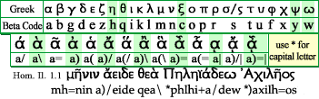

The key difference here is that accents are already stripped away. Plus, I have included a few characters that Perseus either avoids or doesn’t publicize the code for. Digamma, for instance, is already coded into the Perseus Project as “v/V”.

### QUICK NOTES THOMAS WRITE THIS OUT IN FULL LATER

- GrkToLat() turns Greek text into Latin text (transcription)
- LatToGrk() turns Latin text into Greek text (transcription)
- Search() takes a data frame (df), then searches for a target segment (target). The target includes either a dummy consonant C or dummy vowel V. Then two hypothetical phones (hyp1 and hyp2) are substituted for C/V. Search then looks for both in the data set, and returns matches for each.